# Question

Consider the quadratic function graphed below.

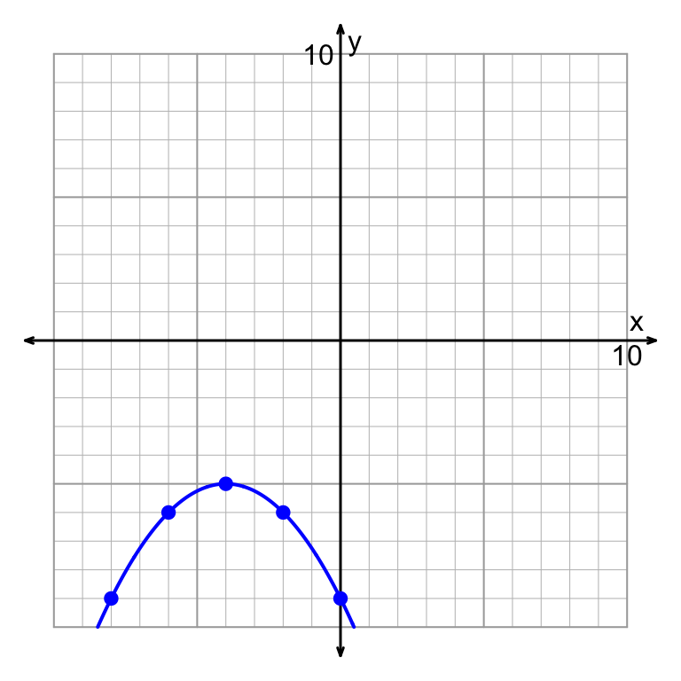

Find parameters $a$, $b$, and $c$, such that the above curve represents $y=ax^2+bx+c$.

- $a=$ ##ANSWER1##
- $b=$ ##ANSWER2##
- $c=$ ##ANSWER3##

## Answerlist

- -3
- -2
- -1
- -1/2
- -1/3
- -1/4
- 1/4
- 1/3
- 1/2
- 1
- 2
- 3
- -10
- -9
- -8
- -7
- -6
- -5
- -4
- -3
- -2
- -1
- 0
- 1
- 2
- 3
- 4
- 5
- 6
- 7
- 8
- 9
- 10
- -10
- -9
- -8
- -7
- -6
- -5
- -4
- -3
- -2
- -1
- 0
- 1
- 2
- 3
- 4
- 5
- 6
- 7
- 8
- 9
- 10

# Solution

First, [based on the spacing of lattice-point intersections near the vertex](https://artockthedino.github.io/algtwo2026/u06/1218/Stretched_Parabolas_Reference.html), and also the up/down orientation, we can determine $a$.

$$a~=~\frac{-1}{4}$$

Next, identify the location of the vertex is $(-4,-5)$, so $h=-4$. We know that $h=\frac{-b}{2a}$, so with a bit of algebra, we also know that $b=-2ah$.

$$b~=~-2(-1/4)(-4)$$
$$b~=~-2$$

Lastly, getting $c$ is easy. Notice, if $x=0$, then $y=c$. Thus, we just need to find the $y$ intercept to get $c$.

$$c=-9$$

The function:

$$y={\frac{-1}{4}}x^{2}-{2}x-{9}$$

# Meta-information

extype: cloze exclozetype: schoice|schoice|schoice exsolution: 000001000000|000000001000000000000|010000000000000000000 exname: standard_from_graph